# Princeton CO2 Emission Analysis

Jiahuan Kang

11/11/2015

### Summary

The purpose of this analysis was to build a mathematical model for total CO2 emission through electricity/gas consumption in Princeton Township and Boro. Suggestions on how to reduce CO2 emission are given as a conclusion.

Multiple linear regression method with stepwise model selection by AIC criterion were used, significant variables were recorded and final model was presented. 3D graphic demonstration of the final statistical model was illustrated. Weather normalized (by Temperature, Daylight length) data were generated in order to discover other factors that affact CO2 emission in further analysis.

### Basic statistics

Three key variables and their preliminary statistics are displayed as follows, the time span of the data was from April, 2009 - Jun, 2015.

MCO2 : Total CO2 emission(in thousand tons)

```
   Min. 1st Qu.  Median    Mean 3rd Qu.    Max.
  20.93   27.72   29.91   31.82   35.09   49.39
```

Temp : Temperature ($F^{\circ}$)

```
   Min. 1st Qu.  Median    Mean 3rd Qu.    Max.
  24.50   41.05   56.40   55.24   70.40   79.80
```

Daylength : Daylight length (Hours)

```
   Min. 1st Qu.  Median    Mean 3rd Qu.    Max.
   9.35   10.67   12.45   12.27   14.42   15.00
```

### Multiple regression modeling

Multiple regress model were used with stepwise selection by AIC criterion. The variables entered were: $Temp \qquad Temp^2 \qquad Daylength^2 \qquad Daylength^3$ The final model produced was: $MCO2=53.68-1.73\times Temp+0.01\times Temp^2+0.70\times Daylength^2 -0.03\times Daylength^3$

The chart below illustrates the relationship between CO2 emission and weather parameters (Temperature and Daylight length). The dots were data points and the 3d surface was the regression model.

[interactive chart not shown]

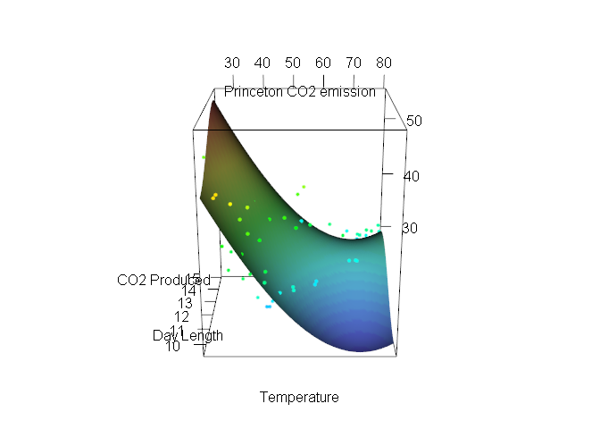

### Conclusion

The CO2 emission through electricity/gas consumption in Princeton decreases as temperature rises and reaches its lowest around $68F^{\circ}$, it also increases in longer days but reaches its highest around 13 hr/day. The data points shows a clear decrease pattern from top-left corner of the cube to the bottom-right corner, which was resulted from the high correlation between Temperature and Daylight length.

The results suggests the following ways that could reduce energy consumption and thus CO2 emission:

- Lower room temperature by 1 to 2 degrees during winter time.
- Use smart switch that shut down heater and lights during daytime when people go to work .

### Normalized dataset

```
   Month Temp Daylength  MCO2 Norm.CO2   Res.CO2
1 Apr-09 53.4     13.28 40.53 33.81467  6.715328
2 May-09 62.4     14.42 31.69 29.56714  2.122856
3 Jun-09 68.7     15.00 29.28 26.10212  3.177880
4 Jul-09 73.3     14.72 20.93 27.72589 -6.795888
5 Aug-09 76.1     13.72 28.68 30.60153 -1.921526
```

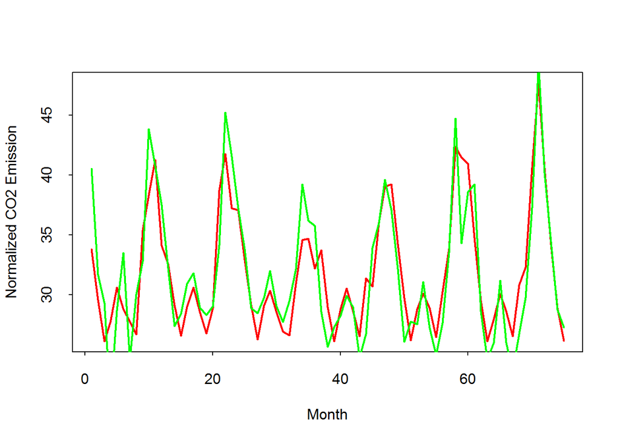

### reference

Link to a second page: * [second page] https://raw.githubusercontent.com/jackking11111111/First-test-manual/gh-pages/Stat_manual.html